# R Notebook

# Modeling Binomial Data

1. Describe data
2. Explore data - Exploratory Data Analysis
3. Estimate parameters
4. Make Inference
5. Make Prediction
6. Interpretation

# Locate files

- Browse your folders.
- Look for the files.
- Check the path to the folder containing the files

# Set the folder

Set our working directory. REMEMBER! your working directory (working folder) is different from my working directory

```r
# this is my working directory. You have to specify yours
setwd("E:/Epi_Stat_Matters/LectureNotes2015/binary-logistic/binary-logistic-DrPH-2015/BinaryLogisticDrPH-Epid/BinaryLog-DrPH-Epid")
getwd()
```

```
[1] "E:/Epi_Stat_Matters/LectureNotes2015/binary-logistic/binary-logistic-DrPH-2015/BinaryLogisticDrPH-Epid/BinaryLog-DrPH-Epid"
```

# Read data

- Read our data in the working folder
- Then, save as a csv file in our working directory

```r
mydata <- read.csv("http://www.ats.ucla.edu/stat/data/binary.csv")
write.csv2(mydata,'logistic.csv')
```

# Describe data

```r
#observe data
head(mydata,10)
```

[output not shown]

Rank is taken as numerical variable which does not make sense. We need to convert it to a categorical (factor) variable

```r
summary(mydata)
```

```
     admit             gre             gpa             rank
 Min.   :0.0000   Min.   :220.0   Min.   :2.260   Min.   :1.000
 1st Qu.:0.0000   1st Qu.:520.0   1st Qu.:3.130   1st Qu.:2.000
 Median :0.0000   Median :580.0   Median :3.395   Median :2.000
 Mean   :0.3175   Mean   :587.7   Mean   :3.390   Mean   :2.485
 3rd Qu.:1.0000   3rd Qu.:660.0   3rd Qu.:3.670   3rd Qu.:3.000
 Max.   :1.0000   Max.   :800.0   Max.   :4.000   Max.   :4.000
```

```r
mydata$rank<-factor(mydata$rank)
summary(mydata$rank)
```

```
  1   2   3   4
 61 151 121  67
```

More fancy, we can use *psych* package

```r
library(psych)
describe(mydata)
```

```
      vars   n   mean     sd median trimmed    mad    min max
admit    1 400   0.32   0.47    0.0    0.27   0.00   0.00   1
gre      2 400 587.70 115.52  580.0  589.06 118.61 220.00 800
gpa      3 400   3.39   0.38    3.4    3.40   0.40   2.26   4
rank*    4 400   2.48   0.94    2.0    2.48   1.48   1.00   4
       range  skew kurtosis   se
admit   1.00  0.78    -1.39 0.02
gre   580.00 -0.14    -0.36 5.78
gpa     1.74 -0.21    -0.60 0.02
rank*   3.00  0.10    -0.91 0.05
```

# Explore data

Use plots like * Histogram for numerical variables * and barplot for categorical variables, at least.

# Estimate parameters

- we estimate the logit or the log odds.
- We used **summary** to see the results stored as **mylogit**
- We used **coefficients** to examine the regression coefficients

```r
mylogit <- glm(admit~gre+gpa+rank,family = 'binomial'(link = logit),data=mydata)
summary(mylogit)
```

```
Call:
glm(formula = admit ~ gre + gpa + rank, family = binomial(link = logit),
    data = mydata)

Deviance Residuals:
    Min       1Q   Median       3Q      Max
-1.6268  -0.8662  -0.6388   1.1490   2.0790

Coefficients:
             Estimate Std. Error z value Pr(>|z|)
(Intercept) -3.989979   1.139951  -3.500 0.000465 ***
gre          0.002264   0.001094   2.070 0.038465 *
gpa          0.804038   0.331819   2.423 0.015388 *
rank2       -0.675443   0.316490  -2.134 0.032829 *
rank3       -1.340204   0.345306  -3.881 0.000104 ***
rank4       -1.551464   0.417832  -3.713 0.000205 ***
---
Signif. codes:  0 â€˜***â€™ 0.001 â€˜**â€™ 0.01 â€˜*â€™ 0.05 â€˜.â€™ 0.1 â€˜ â€™ 1

(Dispersion parameter for binomial family taken to be 1)

    Null deviance: 499.98  on 399  degrees of freedom
Residual deviance: 458.52  on 394  degrees of freedom
AIC: 470.52

Number of Fisher Scoring iterations: 4
```

```r
coefficients(mylogit)
```

```
 (Intercept)          gre          gpa        rank2        rank3
-3.989979073  0.002264426  0.804037549 -0.675442928 -1.340203916
       rank4
-1.551463677
```

To obtain the odds ratios and their 95% CI, we need to exponentiate using **exp** the regression coefficients or the betas

```r
exp(coefficients(mylogit))
```

```
(Intercept)         gre         gpa       rank2       rank3
  0.0185001   1.0022670   2.2345448   0.5089310   0.2617923
      rank4
  0.2119375
```

```r
exp(confint(mylogit))
```

```
                  2.5 %    97.5 %
(Intercept) 0.001889165 0.1665354
gre         1.000137602 1.0044457
gpa         1.173858216 4.3238349
rank2       0.272289674 0.9448343
rank3       0.131641717 0.5115181
rank4       0.090715546 0.4706961
```

# Make inference

Here, we examine the p-values (hypothesis testing) and the confidence intervals.

- First, using the method of maximum likelihood
- Next, using the SE method (function **confint.default**)

```r
confint(mylogit)
```

```
                    2.5 %       97.5 %
(Intercept) -6.2716202334 -1.792547080
gre          0.0001375921  0.004435874
gpa          0.1602959439  1.464142727
rank2       -1.3008888002 -0.056745722
rank3       -2.0276713127 -0.670372346
rank4       -2.4000265384 -0.753542605
```

```r
confint.default(mylogit)
```

```
                    2.5 %       97.5 %
(Intercept) -6.2242418514 -1.755716295
gre          0.0001202298  0.004408622
gpa          0.1536836760  1.454391423
rank2       -1.2957512650 -0.055134591
rank3       -2.0169920597 -0.663415773
rank4       -2.3703986294 -0.732528724
```

# Make prediction

We now can:

1. Predict the log odds for having the outcome
2. Predict the conditional probability for having the outcome

```r
pred.logit<-predict(mylogit,type='link')
head(pred.logit)
```

```
         1          2          3          4          5          6
-1.5671256 -0.8848442  1.0377118 -1.5273305 -2.0081113 -0.5323458
```

```r
-3.99+0.00226*380+0.8041*3.61-1.34
```

```
[1] -1.568399
```

Notice, that similarity between **predict(x, type=‘response’** and **fitted** Remember, we can calculate the conditional probability of having the outcome

```r
pred.prob<-predict(mylogit,type='response')
head(pred.prob)
```

```
        1         2         3         4         5         6
0.1726265 0.2921750 0.7384082 0.1783846 0.1183539 0.3699699
```

```r
head(fitted(mylogit))
```

```
        1         2         3         4         5         6
0.1726265 0.2921750 0.7384082 0.1783846 0.1183539 0.3699699
```

```r
exp(-1.567)/(1+exp(-1.567))
```

```
[1] 0.1726445
```

# Compare models

We compare a model with **vs** and without **gre**. This is done using the deviance

```r
summary(mylogit)
```

```
Call:
glm(formula = admit ~ gre + gpa + rank, family = binomial(link = logit),
    data = mydata)

Deviance Residuals:
    Min       1Q   Median       3Q      Max
-1.6268  -0.8662  -0.6388   1.1490   2.0790

Coefficients:
             Estimate Std. Error z value Pr(>|z|)
(Intercept) -3.989979   1.139951  -3.500 0.000465 ***
gre          0.002264   0.001094   2.070 0.038465 *
gpa          0.804038   0.331819   2.423 0.015388 *
rank2       -0.675443   0.316490  -2.134 0.032829 *
rank3       -1.340204   0.345306  -3.881 0.000104 ***
rank4       -1.551464   0.417832  -3.713 0.000205 ***
---
Signif. codes:  0 â€˜***â€™ 0.001 â€˜**â€™ 0.01 â€˜*â€™ 0.05 â€˜.â€™ 0.1 â€˜ â€™ 1

(Dispersion parameter for binomial family taken to be 1)

    Null deviance: 499.98  on 399  degrees of freedom
Residual deviance: 458.52  on 394  degrees of freedom
AIC: 470.52

Number of Fisher Scoring iterations: 4
```

```r
mylogit2 <- glm(admit~gpa+rank,family = 'binomial'(link = logit),data=mydata)
summary(mylogit2)
```

```
Call:
glm(formula = admit ~ gpa + rank, family = binomial(link = logit),
    data = mydata)

Deviance Residuals:
    Min       1Q   Median       3Q      Max
-1.5055  -0.8663  -0.6590   1.1505   2.0913

Coefficients:
            Estimate Std. Error z value Pr(>|z|)
(Intercept)  -3.4636     1.1003  -3.148 0.001645 **
gpa           1.0521     0.3102   3.392 0.000694 ***
rank2        -0.6810     0.3141  -2.168 0.030181 *
rank3        -1.3919     0.3419  -4.071 4.68e-05 ***
rank4        -1.5943     0.4152  -3.840 0.000123 ***
---
Signif. codes:  0 â€˜***â€™ 0.001 â€˜**â€™ 0.01 â€˜*â€™ 0.05 â€˜.â€™ 0.1 â€˜ â€™ 1

(Dispersion parameter for binomial family taken to be 1)

    Null deviance: 499.98  on 399  degrees of freedom
Residual deviance: 462.88  on 395  degrees of freedom
AIC: 472.88

Number of Fisher Scoring iterations: 4
```

```r
anova(mylogit,mylogit2,test = 'Chisq')
```

```
Analysis of Deviance Table

Model 1: admit ~ gre + gpa + rank
Model 2: admit ~ gpa + rank
  Resid. Df Resid. Dev Df Deviance Pr(>Chi)
1       394     458.52
2       395     462.88 -1  -4.3578  0.03684 *
---
Signif. codes:  0 â€˜***â€™ 0.001 â€˜**â€™ 0.01 â€˜*â€™ 0.05 â€˜.â€™ 0.1 â€˜ â€™ 1
```

# Linearity in logits

**gre** is tested for linearity in logit. **gre** is linear but it is rescaled to produce less decimals

The linearity of logits is tested using library **mfp**

```r
library(mfp)
mylogit3 <- mfp(admit~fp(gre)+gpa+rank,family = 'binomial'(link = logit),data=mydata,verbose=T)
```

```
    Variable    Deviance    Power(s)
------------------------------------------------
Cycle 1
    rank2
                463.096
                458.517     1



    rank3
                474.043
                458.517     1



    rank4
                473.551
                458.517     1



    gpa
                464.532
                458.517     1



    gre
                462.875
                458.517     1
                458.415     0
                458.366     -2 -2


Tansformation
      shift scale
rank2     0     1
rank3     0     1
rank4     0     1
gpa       0     1
```

[output cut: 8 more lines]

```
gre            4      1  0.05        1      1      .


Transformations of covariates:
             formula
gre  I((gre/1000)^1)
gpa              gpa
rank            rank


Deviance table:
         Resid. Dev
Null model   499.9765
Linear model     458.5175
Final model  458.5175
```

```r
summary(mylogit3)
```

```
Call:
glm(formula = admit ~ rank + gpa + I((gre/1000)^1), family = binomial(link = logit),
    data = mydata)

Deviance Residuals:
    Min       1Q   Median       3Q      Max
-1.6268  -0.8662  -0.6388   1.1490   2.0790

Coefficients:
                Estimate Std. Error z value Pr(>|z|)
(Intercept)      -3.9900     1.1400  -3.500 0.000465 ***
rank2            -0.6754     0.3165  -2.134 0.032829 *
rank3            -1.3402     0.3453  -3.881 0.000104 ***
rank4            -1.5515     0.4178  -3.713 0.000205 ***
gpa               0.8040     0.3318   2.423 0.015388 *
I((gre/1000)^1)   2.2644     1.0940   2.070 0.038465 *
---
Signif. codes:  0 â€˜***â€™ 0.001 â€˜**â€™ 0.01 â€˜*â€™ 0.05 â€˜.â€™ 0.1 â€˜ â€™ 1

(Dispersion parameter for binomial family taken to be 1)

    Null deviance: 499.98  on 399  degrees of freedom
Residual deviance: 458.52  on 394  degrees of freedom
AIC: 470.52

Number of Fisher Scoring iterations: 4
```

```r
mylogit3$fptable
```

|  | df.initial | select | alpha | df.final | power1 | power2 |
| --- | --- | --- | --- | --- | --- | --- |
| rank2 | 1 | 1 | 0.05 | 1 | 1 | . |
| rank3 | 1 | 1 | 0.05 | 1 | 1 | . |
| rank4 | 1 | 1 | 0.05 | 1 | 1 | . |
| gpa | 1 | 1 | 0.05 | 1 | 1 | . |
| gre | 4 | 1 | 0.05 | 1 | 1 | . |

# Diagnostics for a model with a binomial response

To do these diagnostics, you need to load **library(‘LogisticDx’)**.

First, we produce the diagnostic measures for a binary regression model by covariate pattern

Next, we produce the Goodness-of-fit for binomial regression. Usually, the number of groups (quantiles) equal 10 to perform the Hosmer-Lemeshow test. At the same time, we plot the ROC curve

Similarly, we can check the **auc** value

```r
library('LogisticDx')
dx(mylogit2,byCov=T)
```

| (Intercept) | gpa | rank2 | rank3 | rank4 | y | P | n | yhat | Pr | dr | h | sPr | sdr | dChisq | dDev | dBhat |
| --- | --- | --- | --- | --- | --- | --- | --- | --- | --- | --- | --- | --- | --- | --- | --- | --- |
| 1 | 3.94 | 1 | 0 | 0 | 1 | 0.50012417 | 2 | 1.00024833 | -0.0003511985 | -0.0003511985 | 0.014377039 | -0.0003537507 | -0.0003537506 | 1.251395e-07 | 1.251395e-07 | 1.825379e-09 |
| 1 | 3.30 | 1 | 0 | 0 | 1 | 0.33786634 | 3 | 1.01359902 | -0.0165997514 | -0.0166181074 | 0.006902268 | -0.0166573376 | -0.0166757573 | 2.774669e-04 | 2.780809e-04 | 1.928462e-06 |
| 1 | 3.99 | 0 | 1 | 0 | 1 | 0.34122589 | 3 | 1.02367767 | -0.0288329487 | -0.0288874508 | 0.015618469 | -0.0290607843 | -0.0291157171 | 8.445292e-04 | 8.477250e-04 | 1.339953e-05 |
| 1 | 3.35 | 1 | 0 | 0 | 1 | 0.34973268 | 3 | 1.04919805 | -0.0595625368 | -0.0597856465 | 0.006844794 | -0.0597674360 | -0.0599913131 | 3.572146e-03 | 3.598958e-03 | 2.461912e-05 |
| 1 | 3.17 | 1 | 0 | 0 | 1 | 0.30797917 | 3 | 0.92393750 | 0.0951239167 | 0.0944359041 | 0.007474218 | 0.0954814103 | 0.0947908121 | 9.116700e-03 | 8.985298e-03 | 6.865333e-05 |
| 1 | 4.00 | 0 | 0 | 0 | 6 | 0.67799926 | 9 | 6.10199333 | -0.0727624780 | -0.0725435839 | 0.021459082 | -0.0735559800 | -0.0733346987 | 5.410482e-03 | 5.377978e-03 | 1.186501e-04 |
| 1 | 4.00 | 1 | 0 | 0 | 4 | 0.51589960 | 8 | 4.12719677 | -0.0899872045 | -0.0899644454 | 0.015995728 | -0.0907156608 | -0.0906927175 | 8.229331e-03 | 8.225169e-03 | 1.337740e-04 |
| 1 | 3.78 | 1 | 0 | 0 | 1 | 0.45814027 | 2 | 0.91628054 | 0.1188143108 | 0.1186054483 | 0.010787822 | 0.1194604169 | 0.1192504186 | 1.427079e-02 | 1.422066e-02 | 1.556297e-04 |
| 1 | 3.75 | 1 | 0 | 0 | 1 | 0.45031616 | 2 | 0.90063233 | 0.1412260677 | 0.1408758662 | 0.010240239 | 0.1419547634 | 0.1416027549 | 2.015115e-02 | 2.005134e-02 | 2.084876e-04 |
| 1 | 3.05 | 1 | 0 | 0 | 1 | 0.28174338 | 3 | 0.84523014 | 0.1986365068 | 0.1953092157 | 0.008468306 | 0.1994829438 | 0.1961414744 | 3.979344e-02 | 3.847148e-02 | 3.398611e-04 |

[output cut: 250 more lines]

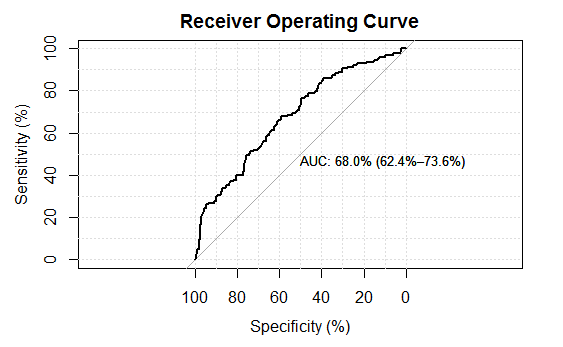

```r
fit.mylogit2<-gof(mylogit2,g=10,plotROC = T)
```

```r
fit.mylogit2
```

```
      chiSq  df     pVal
PrI  400.78 395 0.409645
drI  462.88 395 0.010379 *
PrG  255.36 255 0.481870
drG  294.60 255 0.044609 *
PrCT 255.36 255 0.481870
drCT 294.60 255 0.044609 *
---
Signif. codes:  0 â€˜***â€™ 0.001 â€˜**â€™ 0.01 â€˜*â€™ 0.05 â€˜.â€™ 0.1 â€˜ â€™ 1
                      val df     pVal
HL chiSq         8.190458  8 0.415090
mHL F            1.484491  9 0.153918
OsRo Z           0.027903 NA 0.977740
SstPgeq0.5 Z     0.217564 NA 0.827769
SstPl0.5 Z       0.422859 NA 0.672398
SstBoth chiSq    0.226144  2 0.893086
SllPgeq0.5 chiSq 0.047739  1 0.827045
SllPl0.5 chiSq   0.176745  1 0.674186
SllBoth chiSq    0.177398  2 0.915121
```

```r
#area under curve
fit.mylogit2$auc
```

```
         auc lower 95% CI upper 95% CI
    68.01073     62.39737     73.62409
attr(,"interpret")
[1] "auc = 0.5       --> useless"   "0.7 < auc < 0.8 --> good"
[3] "0.8 < auc < 0.9 --> excellent"
```

```r
#chi square test for gof
fit.mylogit2$chiSq
```

| test | chiSq | df | pVal |
| --- | --- | --- | --- |
| PrI | 400.7833 | 395 | 0.40964543 |
| drI | 462.8753 | 395 | 0.01037867 |
| PrG | 255.3601 | 255 | 0.48187033 |
| drG | 294.6050 | 255 | 0.04460896 |
| PrCT | 255.3601 | 255 | 0.48187033 |
| drCT | 294.6050 | 255 | 0.04460896 |

```r
#contigency table for HL test
fit.mylogit2$ctHL
```

| P | y1 | y1hat | y0 | y0hat | n | Pbar |
| --- | --- | --- | --- | --- | --- | --- |
| 0.149 | 6 | 5.037833 | 34 | 34.96217 | 40 | 0.1259458 |
| 0.192 | 5 | 6.824095 | 35 | 33.17591 | 40 | 0.1706024 |
| 0.219 | 7 | 8.260683 | 33 | 31.73932 | 40 | 0.2065171 |
| 0.258 | 11 | 9.327547 | 28 | 29.67245 | 39 | 0.2391679 |
| 0.293 | 12 | 11.338710 | 29 | 29.66129 | 41 | 0.2765539 |
| 0.34 | 15 | 12.556219 | 25 | 27.44378 | 40 | 0.3139055 |
| 0.376 | 14 | 13.796927 | 25 | 25.20307 | 39 | 0.3537674 |
| 0.437 | 14 | 16.561867 | 27 | 24.43813 | 41 | 0.4039480 |
| 0.511 | 13 | 18.253216 | 25 | 19.74678 | 38 | 0.4803478 |
| 0.678 | 30 | 25.042903 | 12 | 16.95710 | 42 | 0.5962596 |

```r
#GOF test
fit.mylogit2$gof
```

| test | stat | val | df | pVal |
| --- | --- | --- | --- | --- |
| HL | chiSq | 8.19045835 | 8 | 0.4150903 |
| mHL | F | 1.48449073 | 9 | 0.1539182 |
| OsRo | Z | 0.02790263 | NA | 0.9777398 |
| SstPgeq0.5 | Z | 0.21756392 | NA | 0.8277689 |
| SstPl0.5 | Z | 0.42285933 | NA | 0.6723979 |
| SstBoth | chiSq | 0.22614408 | 2 | 0.8930863 |
| SllPgeq0.5 | chiSq | 0.04773921 | 1 | 0.8270450 |
| SllPl0.5 | chiSq | 0.17674490 | 1 | 0.6741857 |
| SllBoth | chiSq | 0.17739848 | 2 | 0.9151208 |

```r
# another package for ROC
library(ROCR)
pred.prob2<-predict(mylogit2, type='response')
head(pred.prob2)
```

```
        1         2         3         4         5         6
0.2577653 0.2700256 0.6779993 0.1542276 0.1218149 0.2712217
```

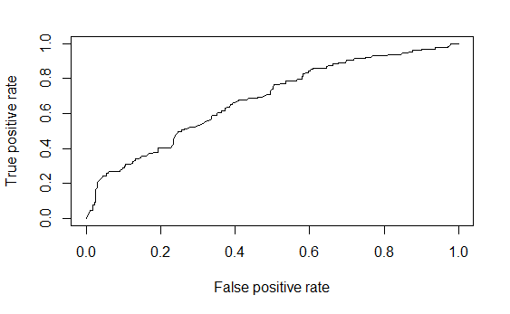

```r
pred.prob22<-prediction(pred.prob2, mydata$admit )
pred.prob22f<-performance(pred.prob22, measure='tpr', x.measure='fpr')
plot(pred.prob22f)
```

```r
auc2<-performance(pred.prob22, measure='auc')
auc2@y.values[[1]]
```

```
[1] 0.6801073
```

# Diagnostic plot

Will return many diagnostic plot

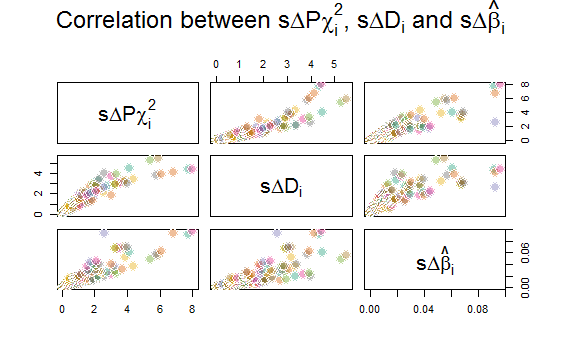

```r
plot(mylogit2)
```

# Interaction

Let use see how we deal an interaction. First, read data from this text file.

```r
data.l<-read.table("LOWBWT.txt",header=T)
data.l[,c(2,5:10)]<-lapply(data.l[,c(2,5)],factor)
```

To simulate a binary predictor variable, we now recode LWT to LWD (LWT<110 vs >=110)

```r
data.l$LWD<-findInterval(data.l$LWT,110)
data.l$LWD<-factor(data.l$LWD,labels = c("less 110",">=110"))
head(data.l$LWD,10)
```

```
 [1] >=110    >=110    >=110    less 110 less 110 >=110    less 110
 [8] >=110    >=110    >=110
Levels: less 110 >=110
```

```r
head(data.l$LWT,10)
```

```
 [1] 120 130 187 105  85 150  97 128 132 165
```

```r
str(data.l$LWD)
```

```
 Factor w/ 2 levels "less 110",">=110": 2 2 2 1 1 2 1 2 2 2 ...
```

Model the relationship; outcome (LOW=0,1) with predictors of LWD and AGE interact with each other. You may try with using #

```r
mod.lwd.age<-glm(LOW~LWD*AGE,family = binomial(link =logit ),data=data.l)
summary(mod.lwd.age)
```

```
Call:
glm(formula = LOW ~ LWD * AGE, family = binomial(link = logit),
    data = data.l)

Deviance Residuals:
    Min       1Q   Median       3Q      Max
-1.4257  -0.8554  -0.6960   1.1602   2.0329

Coefficients:
             Estimate Std. Error z value Pr(>|z|)
(Intercept)  -1.16959    1.46515  -0.798   0.4247
LWD>=110      1.94409    1.72481   1.127   0.2597
AGE           0.05262    0.06449   0.816   0.4145
LWD>=110:AGE -0.13220    0.07570  -1.746   0.0807 .
---
Signif. codes:  0 â€˜***â€™ 0.001 â€˜**â€™ 0.01 â€˜*â€™ 0.05 â€˜.â€™ 0.1 â€˜ â€™ 1

(Dispersion parameter for binomial family taken to be 1)

    Null deviance: 234.67  on 188  degrees of freedom
Residual deviance: 221.14  on 185  degrees of freedom
AIC: 229.14

Number of Fisher Scoring iterations: 4
```

Predict our model using new data. Before doing so, we need to create a dataset containing new data

```r
newdata.2<-data.frame(AGE=c(15,15,20,20),LWD=rep(c("less 110",">=110"),2))
```

Now let us predict the log odds

```r
predict(mod.lwd.age,newdata=newdata.2)
```

```
         1          2          3          4
-0.3802252 -0.4190874 -0.1171023 -0.8169483
```

```r
newdata.2
```

| AGE | LWD |
| --- | --- |
| 15 | less 110 |
| 15 | >=110 |
| 20 | less 110 |
| 20 | >=110 |

Can you prove these?

```r
-1.1696+0+0.0526*15+0
```

```
[1] -0.3806
```

```r
-1.1696+1.944*1+0.0526*15-0.1322*1*15
```

```
[1] -0.4196
```

```r
-1.1696+0+0.0526*20+0
```

```
[1] -0.1176
```

```r
-1.1696+1.944*1+0.0526*20-0.1322*1*20
```

```
[1] -0.8176
```

# Resources

1. http://www.ats.ucla.edu/stat/r/dae/logit.htm
2. https://cran.r-project.org/web/packages/HSAUR/vignettes/Ch_logistic_regression_glm.pdf

# Additional materials

1. http://www.shizukalab.com/toolkits/plotting-logistic-regression-in-r

First, we’ll create a fake dataset of 20 individuals of different body sizes:

```r
bodysize<-rnorm(20,30,2) # generates 20 values, with mean of 30 & s.d.=2
bodysize<-sort(bodysize) # sorts these values in ascending order.
survive<-c(0,0,0,0,0,1,0,1,0,0,1,1,0,1,1,1,0,1,1,1) # assign 'survival' to these 20 individuals non-randomly... most mortality occurs at smaller body size
dat<-as.data.frame(cbind(bodysize,survive)) # saves dataframe with two columns: body size & survival
dat # just shows you what your dataset looks like. It will look something like this:
```

| bodysize | survive |
| --- | --- |
| 25.56842 | 0 |
| 26.40328 | 0 |
| 28.14277 | 0 |
| 28.40899 | 0 |
| 28.75665 | 0 |
| 29.13129 | 1 |
| 29.14562 | 0 |
| 29.16878 | 1 |
| 29.73221 | 0 |
| 29.80278 | 0 |

[output cut: 10 more lines]

Plot

```r
#quartz(title="bodysize vs. survival") # creates a quartz window with title
plot(bodysize,survive,xlab="Body size",ylab="Probability of survival") # plot with body size on x-axis and survival (0 or 1) on y-axis
g=glm(survive~bodysize,family=binomial,dat) # run a logistic regression model (in this case, generalized linear model with logit link). see ?glm
curve(predict(g,data.frame(bodysize=x),type="resp"),add=TRUE) # draws a curve based on prediction from logistic regression model
```

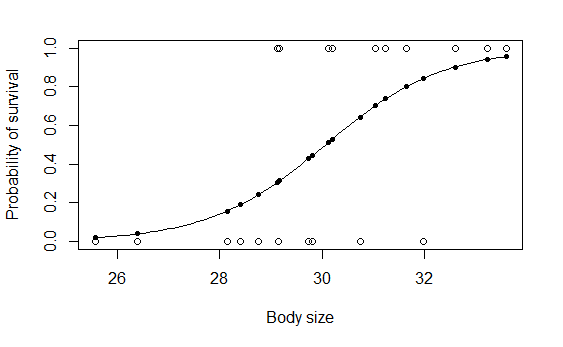

```r
points(bodysize,fitted(g),pch=20) # optional: you could skip this draws an invisible set of points of body size survival based on a 'fit' to glm model. pch= changes type of dots.
```

2. http://www.cookbook-r.com/Statistical_analysis/Logistic_regression/

```r
data(mtcars)
dat2 <- subset(mtcars, select=c(mpg, am, vs))
dat2
```

|  | mpg | am | vs |
| --- | --- | --- | --- |
| Mazda RX4 | 21.0 | 1 | 0 |
| Mazda RX4 Wag | 21.0 | 1 | 0 |
| Datsun 710 | 22.8 | 1 | 1 |
| Hornet 4 Drive | 21.4 | 0 | 1 |
| Hornet Sportabout | 18.7 | 0 | 0 |
| Valiant | 18.1 | 0 | 1 |
| Duster 360 | 14.3 | 0 | 0 |
| Merc 240D | 24.4 | 0 | 1 |
| Merc 230 | 22.8 | 0 | 1 |
| Merc 280 | 19.2 | 0 | 1 |

[output cut: 22 more lines]

Continuous predictor

```r
# Do the logistic regression - both of these have the same effect.
# ("logit" is the default model when family is binomial.)
logr_vm <- glm(vs ~ mpg, data=dat2, family=binomial)
logr_vm <- glm(vs ~ mpg, data=dat2, family=binomial(link="logit"))
```

Plotting, first using ggplot2 then base graphics

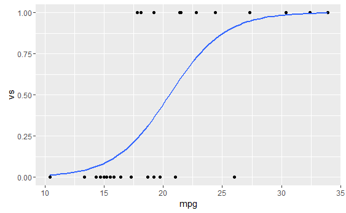

```r
library(ggplot2)
ggplot(dat2, aes(x=mpg, y=vs)) + geom_point()+
  stat_smooth(method="glm",method.args  ="binomial",se=FALSE)
```

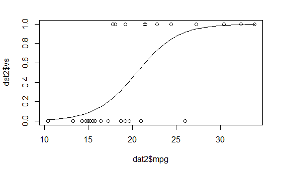

```r
plot(dat2$mpg, dat2$vs)
curve(predict(logr_vm, data.frame(mpg=x), type="response"), add=TRUE)
```